### Prosper是美国的一家P2P（个人对个人）在线借贷平台网站，本案例试图从EDA分析角度出发，分析Propser数据集中贷款人条件及贷款利率等问题。

```r
knitr::opts_chunk$set(message = FALSE, warning = FALSE, echo = FALSE)
```

```
## [1] "C:/Users/cindy/R"
```

```
## [1] 113937     81
```

[output not shown]

[output cut: 67 more lines]

#### 该数据集有113937个观测值，81个变量。本此分析选取以下10个变量来探索贷款人条件和贷款利率等问题。变量如下：

#### BorrowerRate：借款人的贷款利率，影响着借贷双方经济利益，为本次分析的重要指标

#### Occupation:借款人的职业

#### Term:贷款期限（月）

#### EmploymentStatus：借款人就业状态

#### BorrowerState：借款人所在地址，采用2个字母缩写

#### ListingCategory：贷款类型，共21种状态

#### IncomeRange：借款人的收入范围

#### CreditGrade/ProsperRating..Alpha.：借款人评级，区别是前者为09年7月之前，后者为09年7月之后

#### CreditScore: 借款人评分，由信用评分计算均值获得

#### LenderYield：贷款人收益

## 单变量分析

### 贷款利率

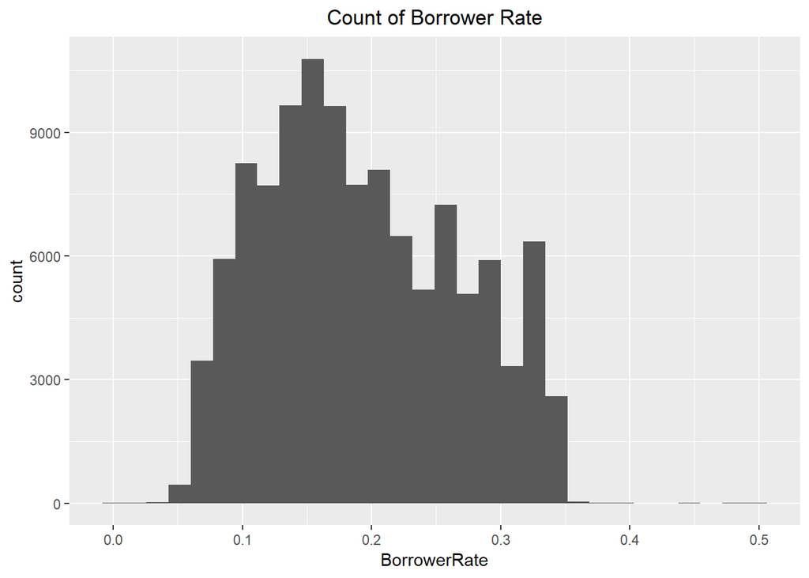

#### 贷款利率集中分布在0.15-0.2之间，接近正太分布。

### 借款人职业

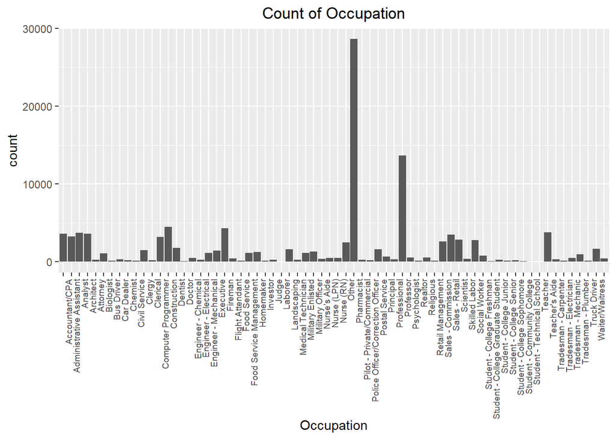

#### 从职业数量上看，最多的的other，其次是Professional。

### 贷款期限

```
##    12    36    60
##  1614 87778 24545
```

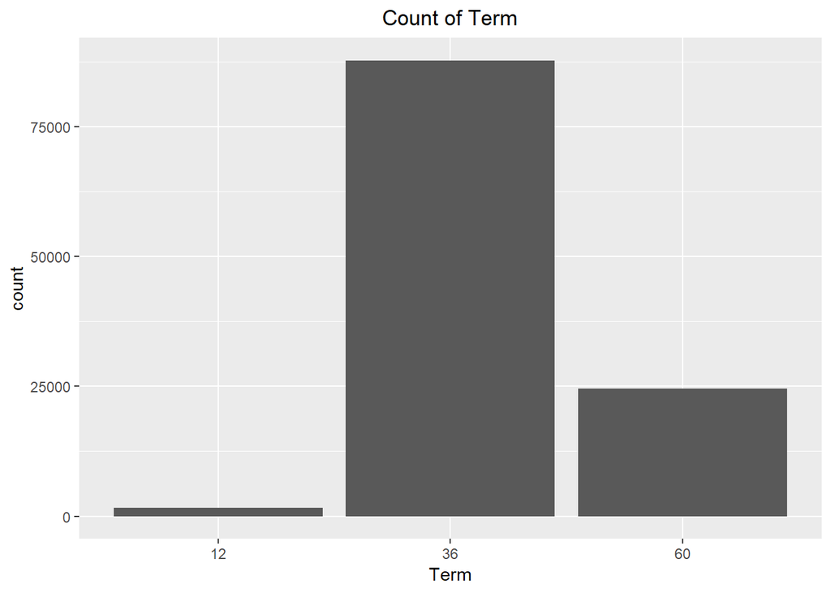

#### 大部分人的贷款期限都是36个月，人数差不多9万人；而贷款期限12个月的人数非常少。

### 就业情况

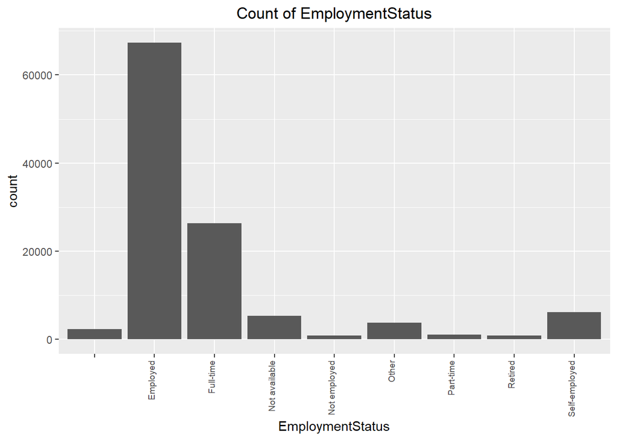

#### 大部分借款人的是在职人员，说明在职人员更容易贷到款。

### 借款人所在地理位置

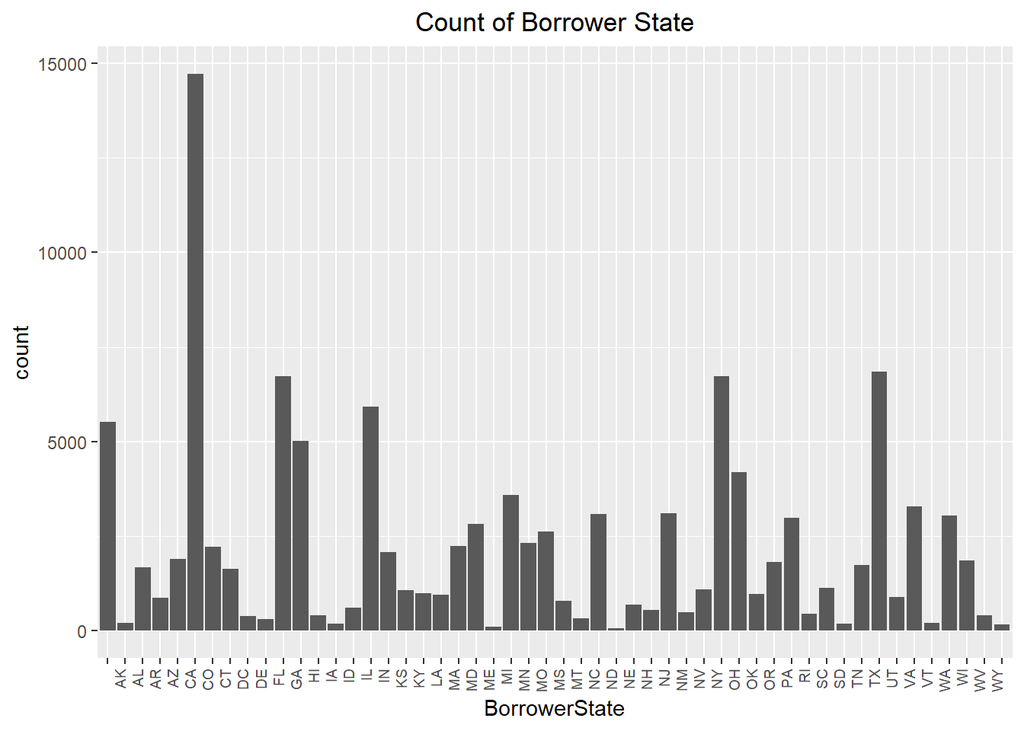

#### CA地区（加利福尼亚）拥有最多借款人数，应该是该地区受金融危机影响比较大，导致借款人明显高于第二多的地区。

### 贷款用途

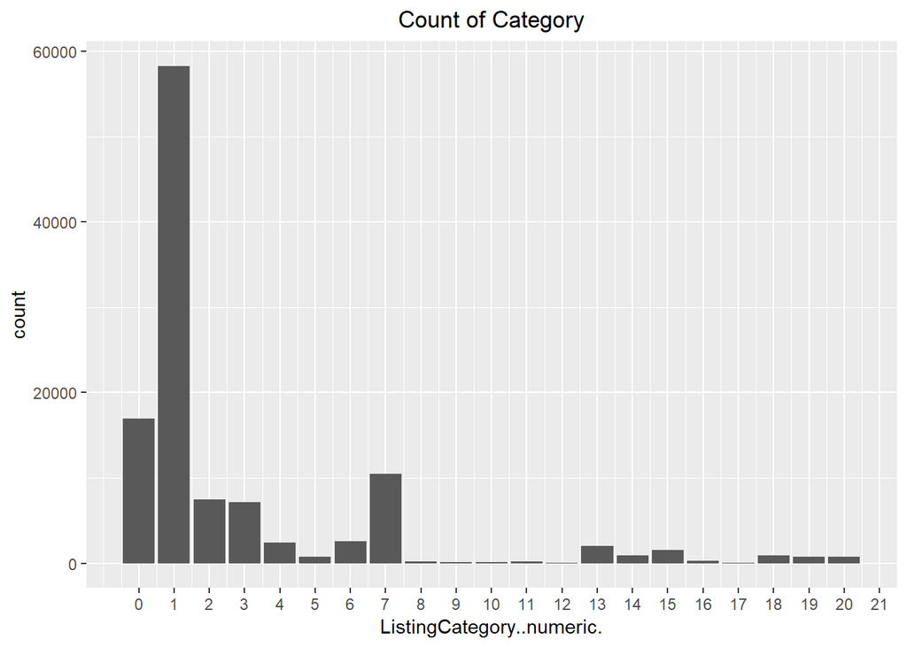

#### 除去0是暂无分类，最多的用途是1债务合并。

### 借款人收入范围

```
##             $0      $1-24,999      $100,000+ $25,000-49,999 $50,000-74,999
##            621           7274          17337          32192          31050
## $75,000-99,999  Not displayed   Not employed
##          16916           7741            806
```

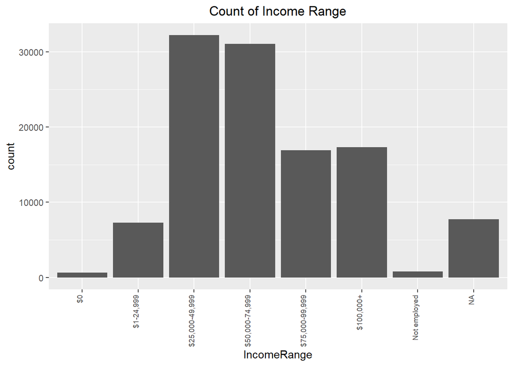

#### 多数人的收入范围集中在$25,000-74,999的范围之间。

### 借款人信用评级

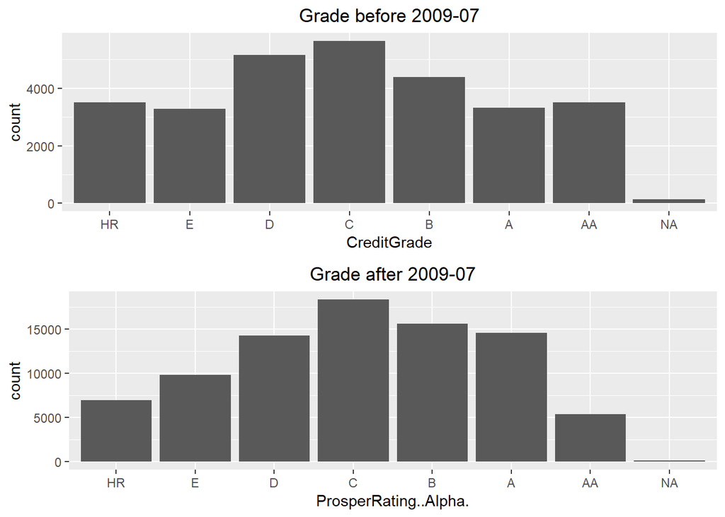

#### 2009年7月之前的信用评分总体上看分布较平均，而2009年7月之后的信用评分的借款人分布微正态分布，即信用等级极高或者极低的借款人数量都很少。

### 信用评分

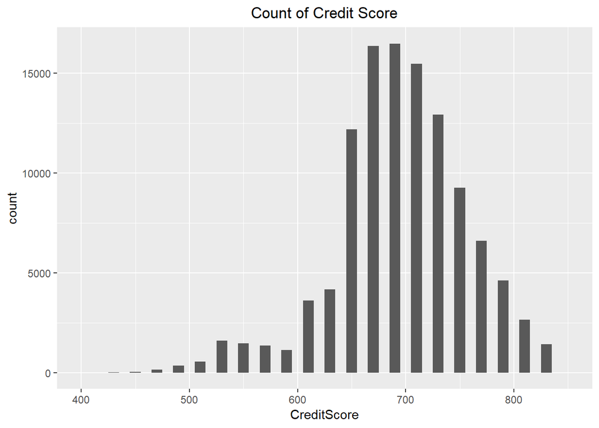

#### 信用评分的用户多数集中在650-750之间，近似正态分布。

### 贷款人收益率

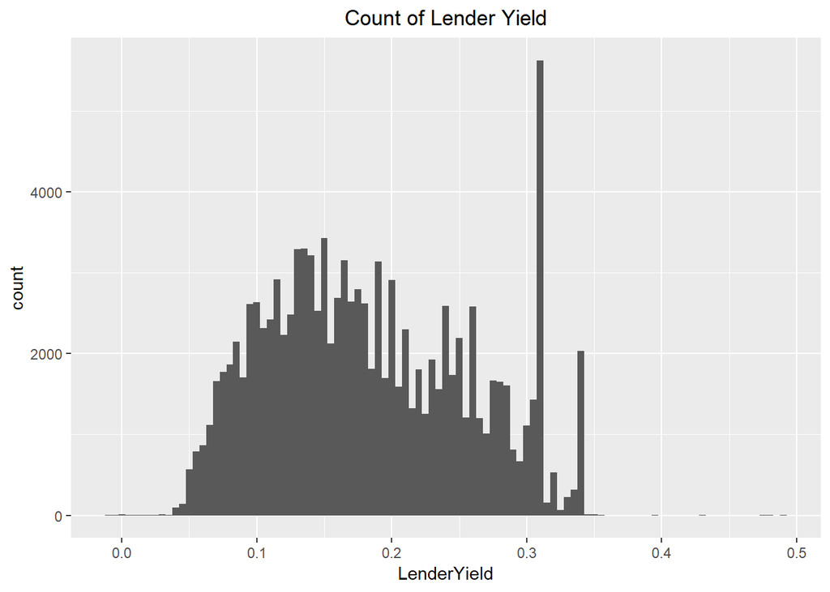

## 双变量绘图

### 贷款利率与期限

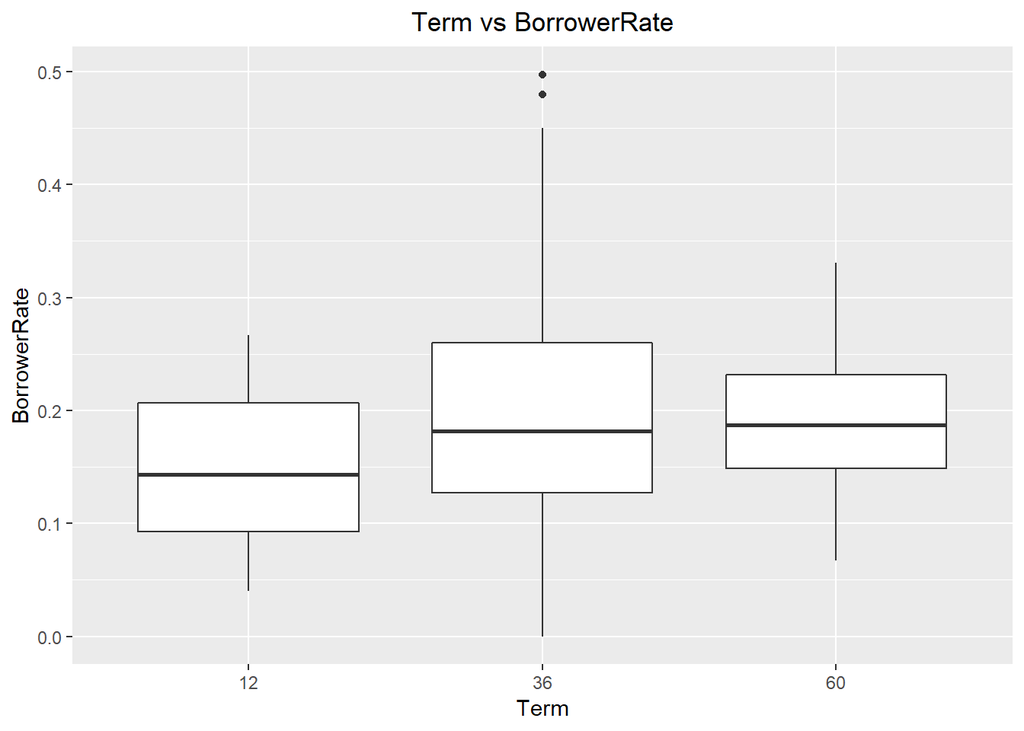

#### 12个月的贷款期限的贷款利率较低，但期限与贷款利率的线性关系不明显。

### 贷款利率与收入

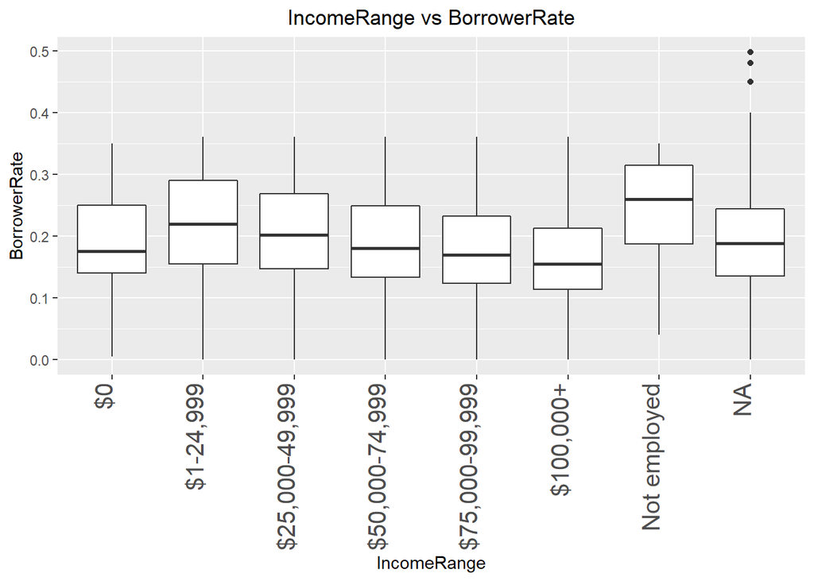

#### 除去NA的情况外，$0的贷款利率没有$1-24,999的贷款利率高，收入范围、贷款利率之间关系不显著，而失业的情况下，贷款利率最高。

### 贷款利率与评级

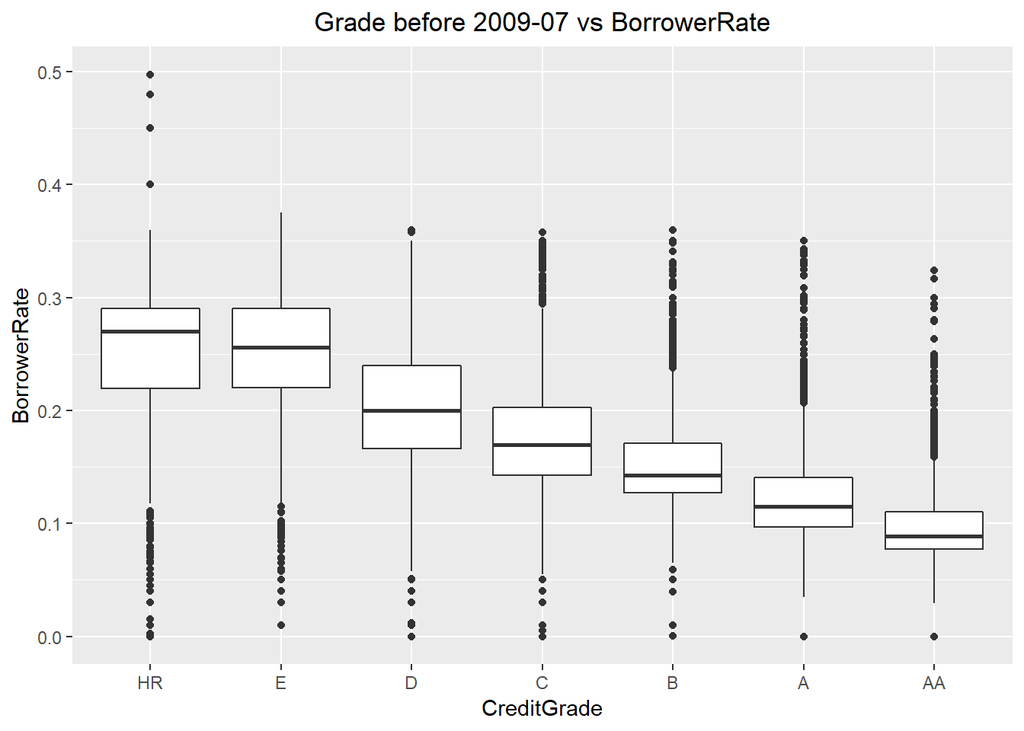

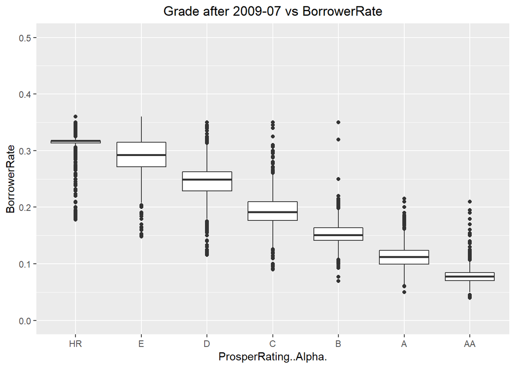

#### 从贷款利率和借款人评级的关系图种可以明显发现借款人评级越高，贷款利率越低。

### 贷款利率与评分

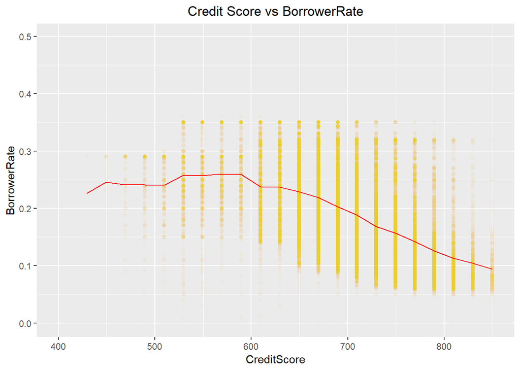

#### 从利率的均值线可以看出，评分越高，贷款利率越低。

### 贷款利率与贷款人收益

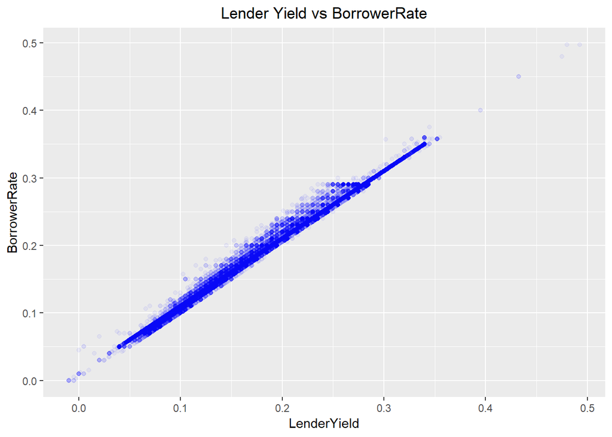

#### 贷款人收益与贷款利率呈明显正相关，显然这与P2P的交易模式有关。

```
##       cor
## 0.9992113
```

#### 查看了贷款人收益和贷款利率的相关度是0.999以上，非常高，符合常理。

## 双变量分析

### 探讨你在这部分探究中观察到的一些关系。这些感兴趣的特性与数据集内其他特性有什么区别？

#### 贷款利率与贷款周期Term、IncomeRange借款人收入的关系不明显。

### 你是否观察到主要特性与其他特性之间的有趣关系？

#### 2009年7月以前和2009年7月以后，评级和利率的负相关趋势变得更明显了，应该是Prosper有调正过评级模型。

### 你发现最强的关系是什么？

#### 贷款人收益和贷款利率强相关，相关度在0.999以上。

## 多变量绘图

### 贷款利率vs信用评分vs收入

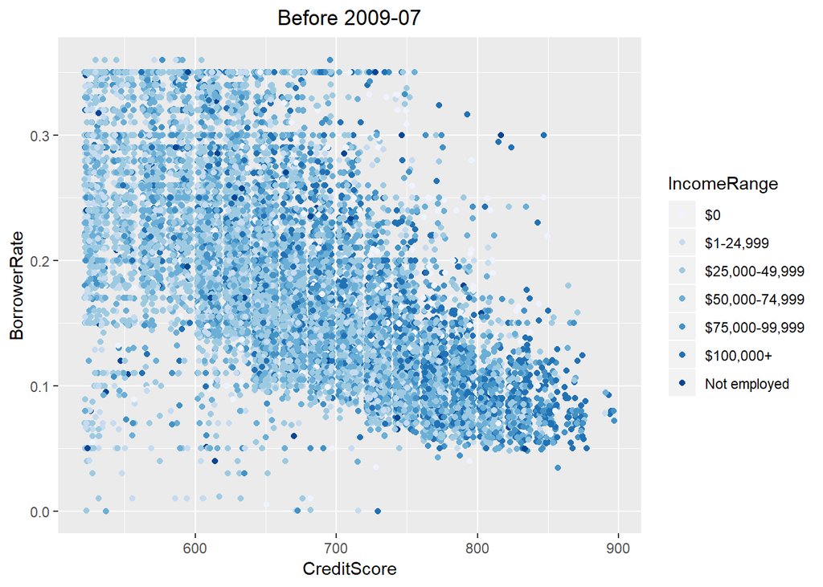

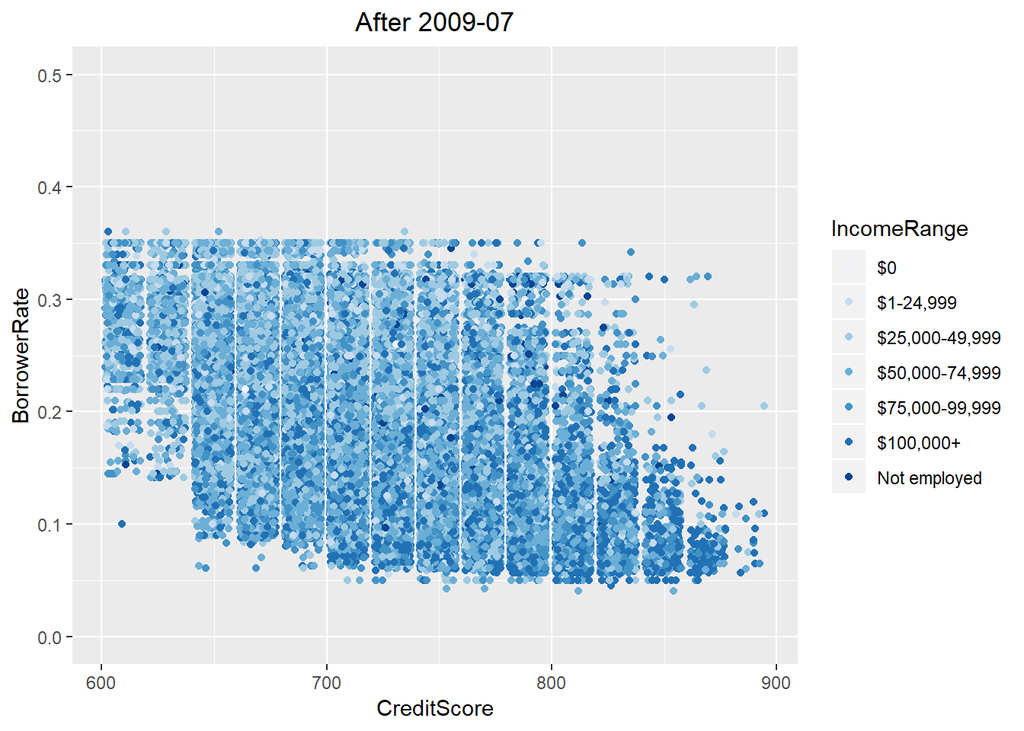

#### 2009年7月之后，信用评分在600分以上，而2009年9月以前，信用评分区间范围更大，从两幅图中观察到，贷款利率、信用评分与收入大小关系不明显。

### 贷款利率vs信用评分vs信用评级

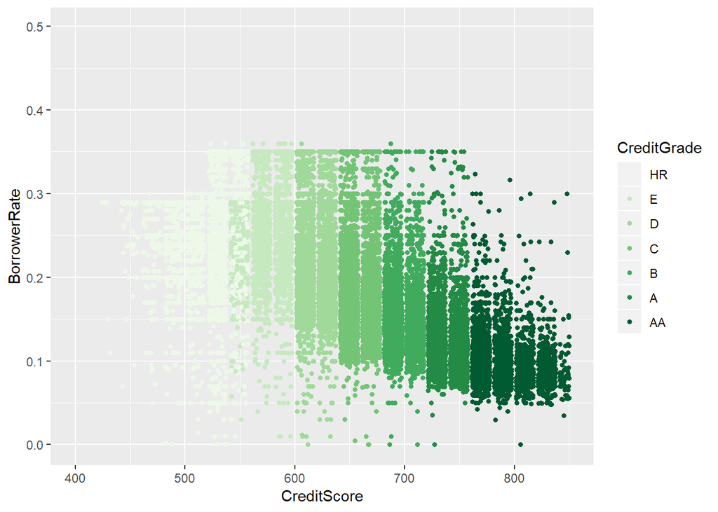

[output not shown]

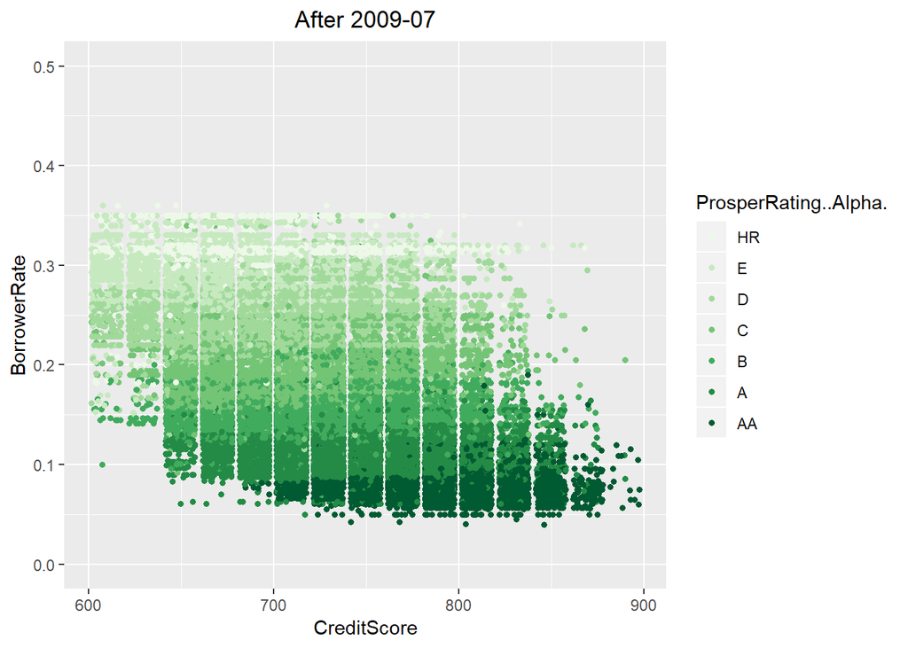

#### 2009年7月之前，评分和评级是相关的，即评级越高，评分也越高；2009年7月之后，评级与贷款利率相关，即评级越高，利率越低，与评分的关系不大。

### 贷款利率vs收入范围vs信用评级vs信用评分

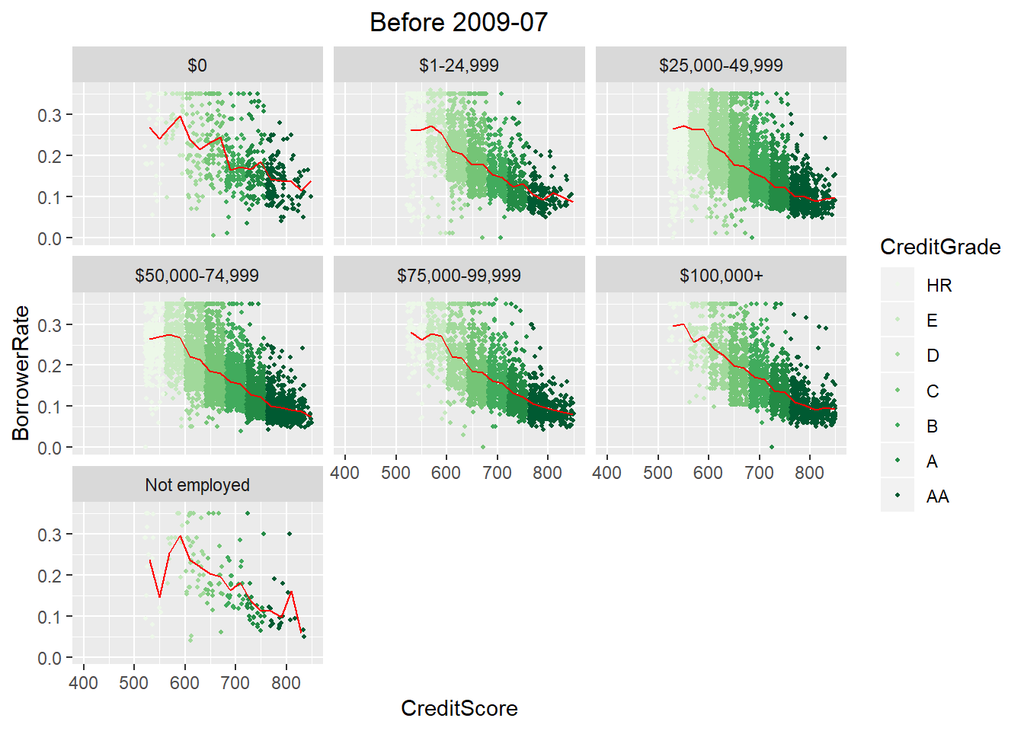

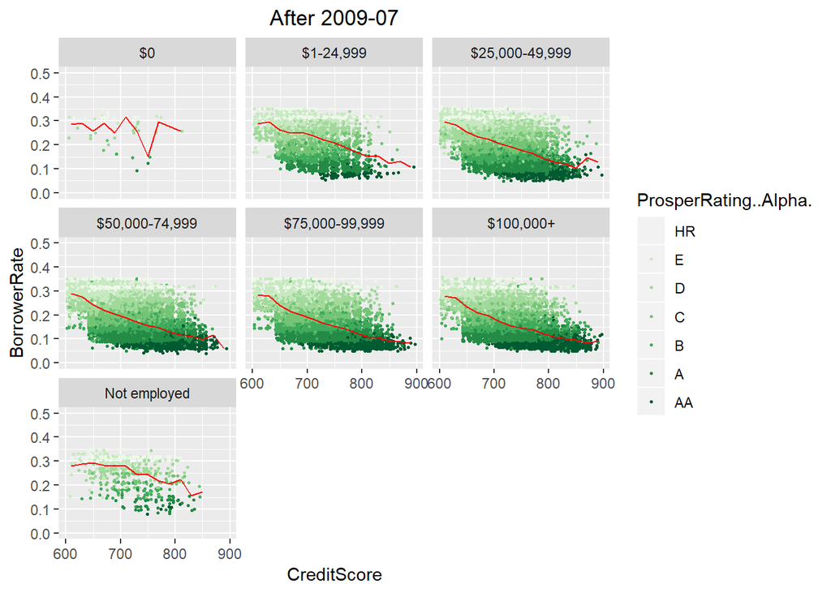

## 多变量分析

### 这些特性之间是否存在有趣或惊人的联系呢？

#### 收入范围与贷款利率的关系并不大。